# Codebook for camden_philly_clean

Autogenerated data summary from dataReporter

2024-04-16 15:57:21.266572

# Data report overview

The dataset examined has the following dimensions:

| Feature | Result |
| --- | --- |
| Number of observations | 1097203 |
| Number of variables | 11 |

# Codebook summary table

| Label | Variable | Class | # unique values | Missing | Description |
| --- | --- | --- | --- | --- | --- |
|  | **date** | Date | 1451 | 0.00 % | The date of the stop, in YYYY-MM-DD format. |
|  | **year** | numeric | 4 | 0.00 % | The year of the stop, in YYYY format. |
|  | **lat** | numeric | 96557 | 0.00 % | The latitude of the stop. |
|  | **lng** | numeric | 96709 | 0.00 % | The longitude of the stop. |
|  | **location** | character | 2 | 0.00 % | City of stop |
|  | **subject_age** | integer | 98 | 0.21 % | The age of the stopped subject. When date of birth is given, we calculate the age based on the stop date. |
|  | **age_group** | character | 9 | 0.21 % |  |
|  | **subject_race** | character | 6 | 0.00 % | The race of the stopped subject. Values are standardized to white, black, hispanic, asian/pacific islander, and other/unknown |
|  | **subject_sex** | factor | 3 | 0.02 % | The recorded sex of the stopped subject. |
|  | **outcome** | factor | 4 | 93.92 % | The outcome of the stop. |
|  | **outcome_recode** | character | 4 | 0.00 % | The outcome of the stop where N/A entries are recoded as ‘No outcome’. |

# Variable list

## date

| Feature | Result |
| --- | --- |
| Variable type | Date |
| Number of missing obs. | 0 (0 %) |
| Number of unique values | 1451 |
| Mode | “2015-03-07” |
| Min. and max. | 2014-01-01; 2017-12-21 |
| 1st and 3rd quartiles | 2015-02-04; 2017-01-15 |

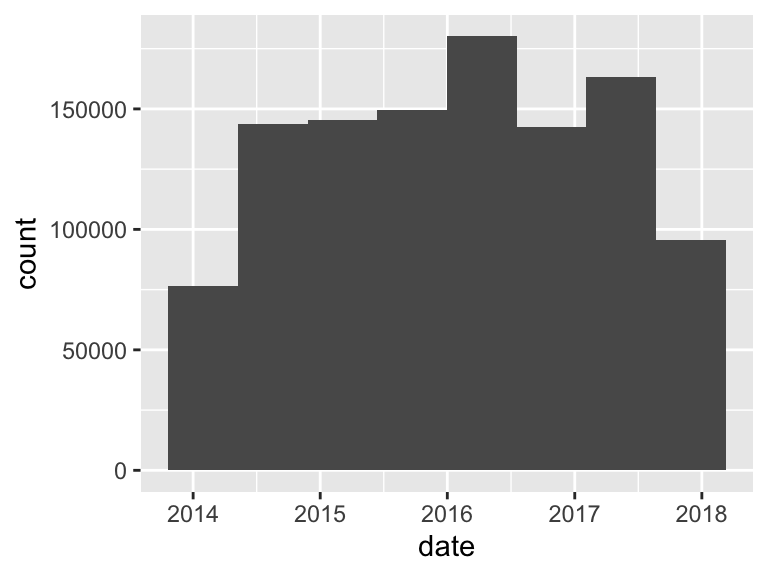

## year

| Feature | Result |
| --- | --- |
| Variable type | numeric |
| Number of missing obs. | 0 (0 %) |
| Number of unique values | 4 |
| Median | 2016 |
| 1st and 3rd quartiles | 2015; 2017 |
| Min. and max. | 2014; 2017 |

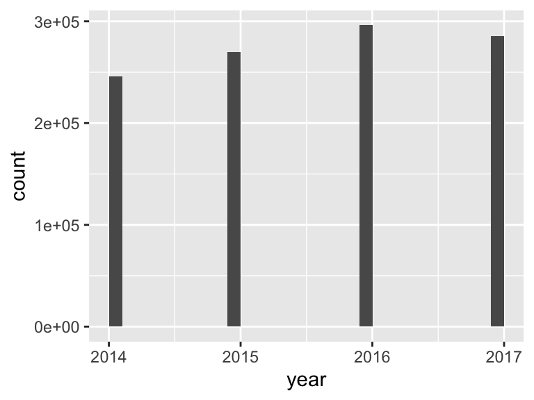

## lat

| Feature | Result |
| --- | --- |
| Variable type | numeric |
| Number of missing obs. | 0 (0 %) |
| Number of unique values | 96557 |
| Median | 39.99 |
| 1st and 3rd quartiles | 39.95; 40.03 |
| Min. and max. | 39.88; 40.14 |

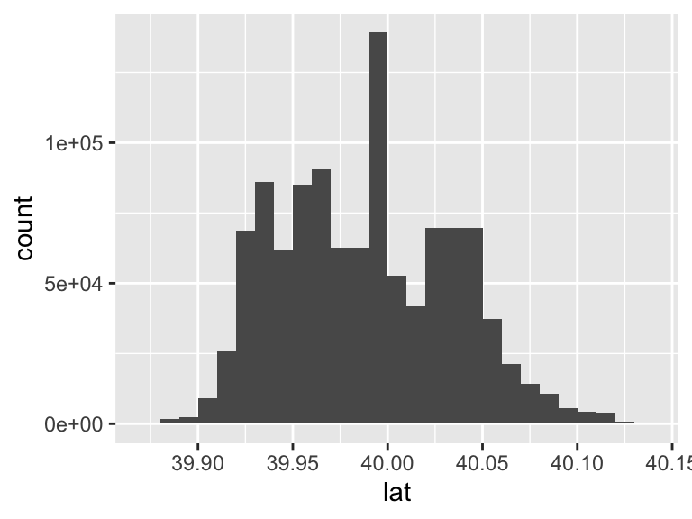

## lng

| Feature | Result |
| --- | --- |
| Variable type | numeric |
| Number of missing obs. | 0 (0 %) |
| Number of unique values | 96709 |
| Median | -75.16 |
| 1st and 3rd quartiles | -75.19; -75.12 |
| Min. and max. | -75.28; -74.96 |

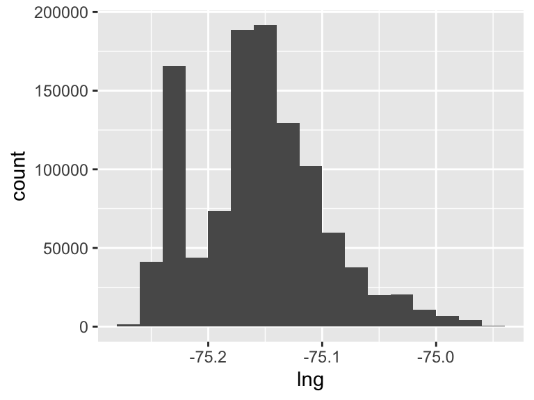

## location

| Feature | Result |
| --- | --- |
| Variable type | character |
| Number of missing obs. | 0 (0 %) |
| Number of unique values | 2 |
| Mode | “philly” |

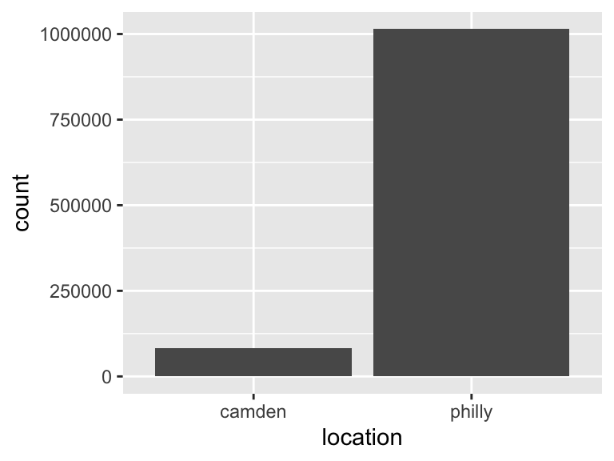

- Observed factor levels: "camden", "philly".

## subject_age

| Feature | Result |
| --- | --- |
| Variable type | integer |
| Number of missing obs. | 2278 (0.21 %) |
| Number of unique values | 97 |
| Median | 32 |
| 1st and 3rd quartiles | 25; 44 |
| Min. and max. | 10; 109 |

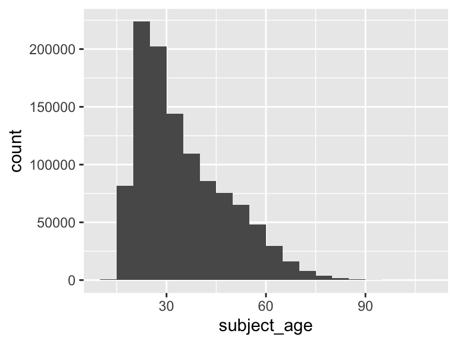

## age_group

| Feature | Result |
| --- | --- |
| Variable type | character |
| Number of missing obs. | 2278 (0.21 %) |
| Number of unique values | 8 |
| Mode | “25-34” |

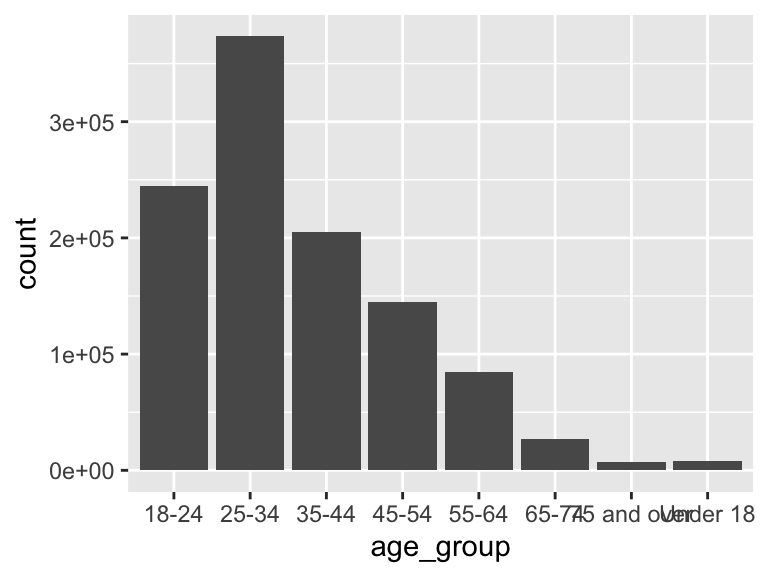

- Observed factor levels: "18-24", "25-34", "35-44", "45-54", "55-64", "65-74", "75 and over", "Under 18".

## subject_race

| Feature | Result |
| --- | --- |
| Variable type | character |
| Number of missing obs. | 0 (0 %) |
| Number of unique values | 6 |
| Mode | “black” |

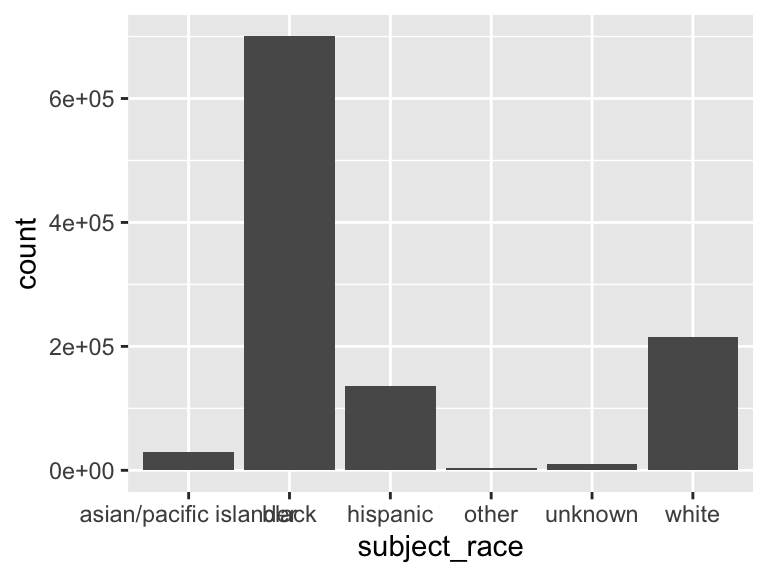

- Observed factor levels: "asian/pacific islander", "black", "hispanic", "other", "unknown", "white".

## subject_sex

| Feature | Result |
| --- | --- |
| Variable type | factor |
| Number of missing obs. | 188 (0.02 %) |
| Number of unique values | 2 |
| Mode | “male” |
| Reference category | male |

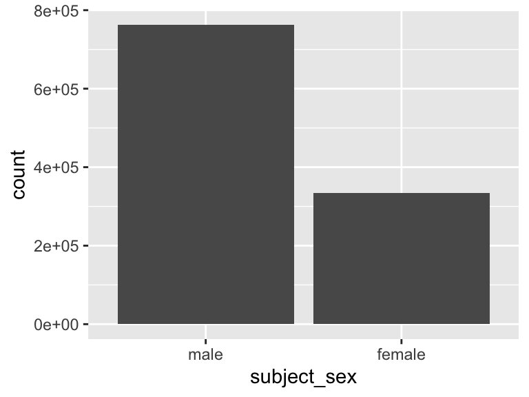

- Observed factor levels: "female", "male".

## outcome

| Feature | Result |
| --- | --- |
| Variable type | factor |
| Number of missing obs. | 1030483 (93.92 %) |
| Number of unique values | 3 |
| Mode | “citation” |
| Reference category | warning |

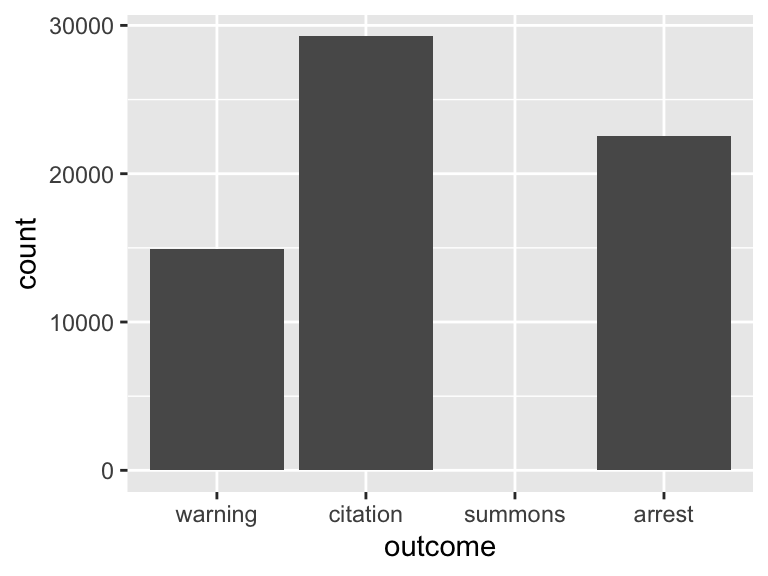

- Observed factor levels: "arrest", "citation", "summons", "warning".

## outcome_recode

| Feature | Result |
| --- | --- |
| Variable type | character |
| Number of missing obs. | 0 (0 %) |
| Number of unique values | 4 |
| Mode | “no outcome” |

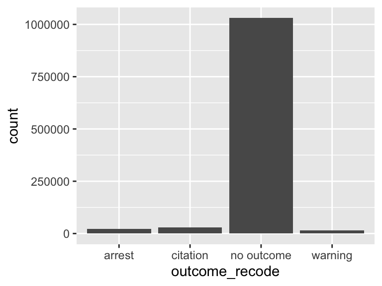

- Observed factor levels: "arrest", "citation", "no outcome", "warning".

Report generation information:

- Created by: Charlotte Pierce (username: `charlottepierce`).
- Report creation time: Tue Apr 16 2024 15:58:02
- Report was run from directory: `/Users/charlottepierce/Desktop/Spring 2024/R DATA VIZ/GLHLTH562/FinalProject/camden`
- dataReporter v1.0.2 [Pkg: 2021-11-11 from CRAN (R 4.3.0)]
- R version 4.3.2 (2023-10-31).
- Platform: x86_64-apple-darwin20 (64-bit)(America/Detroit).
- Function call: `dataReporter::makeDataReport(data = camden_philly_clean, mode = c("summarize", "visualize", "check"), smartNum = FALSE, file = "codebook_camden_philly_clean.Rmd", replace = TRUE, checks = list(character = "showAllFactorLevels", factor = "showAllFactorLevels", labelled = "showAllFactorLevels", haven_labelled = "showAllFactorLevels", numeric = NULL, integer = NULL, logical = NULL, Date = NULL), listChecks = FALSE, maxProbVals = Inf, codebook = TRUE, reportTitle = "Codebook for camden_philly_clean")`